# Data normalization, scaling, and feature selection

6/26/2019

### Normalizing the data:

After removing unwanted cells from the dataset, the next step is to normalize the data. By default, we employ a global-scaling normalization method “LogNormalize” that normalizes the feature expression measurements for each cell by the total expression, multiplies this by a scale factor (10,000 by default), and log-transforms the result. Normalized values are stored in `pbmc[["RNA"]]@data`.

```r
pbmc <- NormalizeData(pbmc, normalization.method = "LogNormalize", scale.factor = 10000)
```

For clarity, in this previous line of code (and in future commands), we provide the default values for certain parameters in the function call. However, this isn’t required and the same behavior can be achieved with:

```r
pbmc <- NormalizeData(pbmc)
# what else can I do with this function?
?NormalizeData
```

### Identification of highly variable features (feature selection):

We next calculate a subset of features that exhibit high cell-to-cell variation in the dataset (i.e, they are highly expressed in some cells, and lowly expressed in others). The Seurat developers and [others](https://www.nature.com/articles/nmeth.2645) have found that focusing on these genes in downstream analysis helps to highlight biological signal in single-cell datasets.

The Seurat3 procedure is described in detail [here](https://www.biorxiv.org/content/biorxiv/early/2018/11/02/460147.full.pdf), and improves on previous versions by directly modeling the mean-variance relationship inherent in single-cell data, and is implemented in the `FindVariableFeatures` function.

By default, we return 2,000 features per dataset. These will be used in downstream analysis, like PCA.

```r
pbmc <- FindVariableFeatures(pbmc, selection.method = "vst", nfeatures = 2000)
# Identify the 10 most highly variable genes
top10 <- head(VariableFeatures(pbmc), 10)
# plot variable features with and without labels
plot1 <- VariableFeaturePlot(pbmc)
plot2 <- LabelPoints(plot = plot1, points = top10, repel = TRUE)
```

```
When using repel, set xnudge and ynudge to 0 for optimal results
```

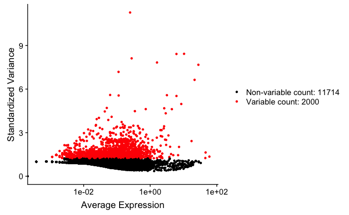

```r
#CombinePlots(plots = list(plot1, plot2))
# Note that you can combine plots, but for clarity let's look at each one on their own:
plot1
```

[figure not shown]

```r
plot2
```

[output not shown]

```r
#You can ignore the error message 'Transformation introduced infinite values in continuous x-axis'
```

### Scaling the data:

Next, we apply a linear transformation (‘scaling’) that is a standard pre-processing step prior to dimensional reduction techniques like PCA. The `ScaleData` function:

- Shifts the expression of each gene, so that the mean expression across cells is 0
- Scales the expression of each gene, so that the variance across cells is 1
- This step gives equal weight in downstream analyses, so that highly-expressed genes do not dominate
- The results of this are stored in `pbmc[["RNA"]]@scale.data`

We can also take care of unwanted sources of variation in this step. Some things to think about regressing include:

- cell-cell variation in gene expression driven by batch (for example, two 10X runs from different days)
- cell alignment rate
- number of detected molecules
- mitochondrial gene expression.

Today, we will regress out differences based on mitochondrial gene expression.

```r
all.genes <- rownames(pbmc)
pbmc <- ScaleData(pbmc, features = all.genes, vars.to.regress = "percent.mt")
```

This will take a few minutes.

What if it’s too slow? Can we make it faster?

```r
?ScaleData
str(VariableFeatures(pbmc))
```

```
 chr [1:2000] "PPBP" "LYZ" "S100A9" "IGLL5" "GNLY" "FTL" "PF4" "FTH1" "GNG11" "S100A8" "FCER1A" "HLA-DRA" "CD74" ...
```

```r
#commented out so this code does not run, see reason below this cell
#pbmc <- ScaleData(pbmc, features = VariableFeatures(pbmc))
```

Scaling is an essential step in the Seurat workflow, but is only truly necessary for genes that will be used as input to PCA (the 2000 `VariableFeatures` we previously calculated).

By default, `ScaleData` will perform scaling on all genes. However, it is possible to perfrom scaling on only the 2000 variable genes, the genes necessary to generate your PCA and clustering results in the next workbook.

### Saving

You can save the object at this point so that it can easily be loaded back in without having to rerun the computationally intensive steps performed above, or easily shared with collaborators.

An example of how to load the data back in is also included, although commented out for now.

```r
saveRDS(pbmc, file = "./output/pbmc_tutorial.rds")
#pbmc = loadRDS("./output/pbmc_tutorial.rds")
```

### Confounding variation regression:

In our workshop today, and in Seurat v2, the `ScaleData` function is used to remove unwanted sources of variation from a single-cell dataset. This functionality is preserved in ScaleData in Seurat v3. However, this `ScaleData` function is essentially deprecated and will slowly be abandoned as Seurat is updated.

An alternative (and arguably better technique), `SCTransform`, is also present in Seurat v3. An example of using the new regression is below.

```r
#Commented out; do not run, this code to simply to provide an in-context example
#pbmc <- SCTransform(pbmc, vars.to.regress = "percent.mt", verbose = TRUE)
```

The Seurat developers recommend the use of the new normalization workflow, SCTransform. The method is described in their recent preprint, with a separate vignette using Seurat v3 here: https://satijalab.org/seurat/v3.0/sctransform_vignette.html. As with ScaleData, you can direct the function SCTransform to regress uninteresting variation with the `vars.to.regress` parameter.

The `SCTransform` step actually replaces `NormalizeData`, `ScaleData`, and `FindVariableFeatures`, although we went through them initially to familiarize ourselves with the concepts. In your future workflow, you can follow the workflow of the [SCTransform vignette](https://satijalab.org/seurat/v3.0/sctransform_vignette.html).